# Analysis of RNA-seq Data

Adam Lu

2018/03/19

All material in this file are taken from [this site](http://bims.fun/r-rnaseq-airway.html).

# Background

## The biology

The data for this lesson comes from:

> *Himes et al. “RNA-Seq Transcriptome Profiling Identifies CRISPLD2 as a Glucocorticoid Responsive Gene that Modulates Cytokine Function in Airway Smooth Muscle Cells.” PLoS ONE. [2014 Jun 13;9(6):e99625](http://journals.plos.org/plosone/article?id=10.1371/journal.pone.0099625). PMID: 24926665.*

**Glucocorticoids** are potent inhibitors of inflammatory processes, and are widely used to treat asthma because of their anti-inflammatory effects on **airway smooth muscle (ASM) cells**. But what’s the molecular mechanism? This study used RNA-seq to profile gene expression changes in four different ASM cell lines treated with **dexamethasone**, a synthetic glucocorticoid molecule. They found a number of differentially expressed genes comparing dexamethasone-treated ASM cells to control cells, but focus much of the discussion on a gene called **CRISPLD2**. This gene encodes a secreted protein known to be involved in **lung development**, and SNPs in this gene in previous GWAS studies are associated with **inhaled corticosteroid resistance** and **bronchodilator response** in asthma patients. They confirmed the upregulated CRISPLD2 mRNA expression with qPCR and increased protein expression using Western blotting.

They did their analysis using [Tophat and Cufflinks](http://rdcu.be/gk0S). We’re taking a different approach and using an R package called [**DESeq2**](https://bioconductor.org/packages/release/bioc/html/DESeq2.html). [Click here](http://bims.fun/help.html#rna-seq-resources) to read more on DESeq2 and other approaches.

## Data pre-processing

Analyzing an RNAseq experiment begins with sequencing reads. There are many ways to begin analyzing this data, and you should check out the three papers below to get a sense of other analysis strategies. In the workflow we’ll use here, sequencing reads were pseudoaligned to a reference transcriptome and the abundance of each transcript quantified using **kallisto** ([software](https://pachterlab.github.io/kallisto/about), [paper](http://www.nature.com/nbt/journal/v34/n5/full/nbt.3519.html)). Transcript-level abundance estimates were then summarized to the gene level to produce length-scaled counts using **txImport** ([software](https://bioconductor.org/packages/tximport), [paper](https://f1000research.com/articles/4-1521/v2)), suitable for using in count-based analysis tools like DESeq. This is the starting point - a “count matrix,” where each cell indicates the number of reads mapping to a particular gene (in rows) for each sample (in columns). This is one of several potential workflows, and relies on having a well-annotated reference transcriptome. However, there are many well-established alternative analysis paths, and the goal here is to provide a reference point to acquire fundamental skills that will be applicable to other bioinformatics tools and workflows.

1. Conesa, A. et al. “A survey of best practices for RNA-seq data analysis.” [*Genome Biology 17:13*](http://genomebiology.biomedcentral.com/articles/10.1186/s13059-016-0881-8) (2016).
2. Soneson, C., Love, M. I. & Robinson, M. D. “Differential analyses for RNA-seq: transcript-level estimates improve gene-level inferences.” [F1000Res. 4:1521](https://f1000research.com/articles/4-1521/v2) (2016).
3. Griffith, Malachi, et al. “Informatics for RNA sequencing: a web resource for analysis on the cloud.” [PLoS Comput Biol 11.8: e1004393](http://journals.plos.org/ploscompbiol/article?id=10.1371/journal.pcbi.1004393) (2015).

This data was downloaded from GEO ([GSE:GSE52778](http://www.ncbi.nlm.nih.gov/geo/query/acc.cgi?acc=GSE52778)). You can read more about how the data was processed by going over the [slides](http://bims.fun/slides/r-rnaseq-airway.pdf). If you’d like to see the code used for the upstream pre-processing with kallisto and txImport, see [the code](https://github.com/bioconnector/workshops/blob/0785f9ffbab87f451f35d52bf48f2fa228e8327a/_dev/airway_kallisto/airway_kallisto_tximport.R).

## Data structure

We’ll come back to this again later, but the data at our starting point looks like this (*note: this is a generic schematic - our genes are not actually `geneA` and `geneB`, and our samples aren’t called `ctrl_1`, `ctrl_2`, etc.*):

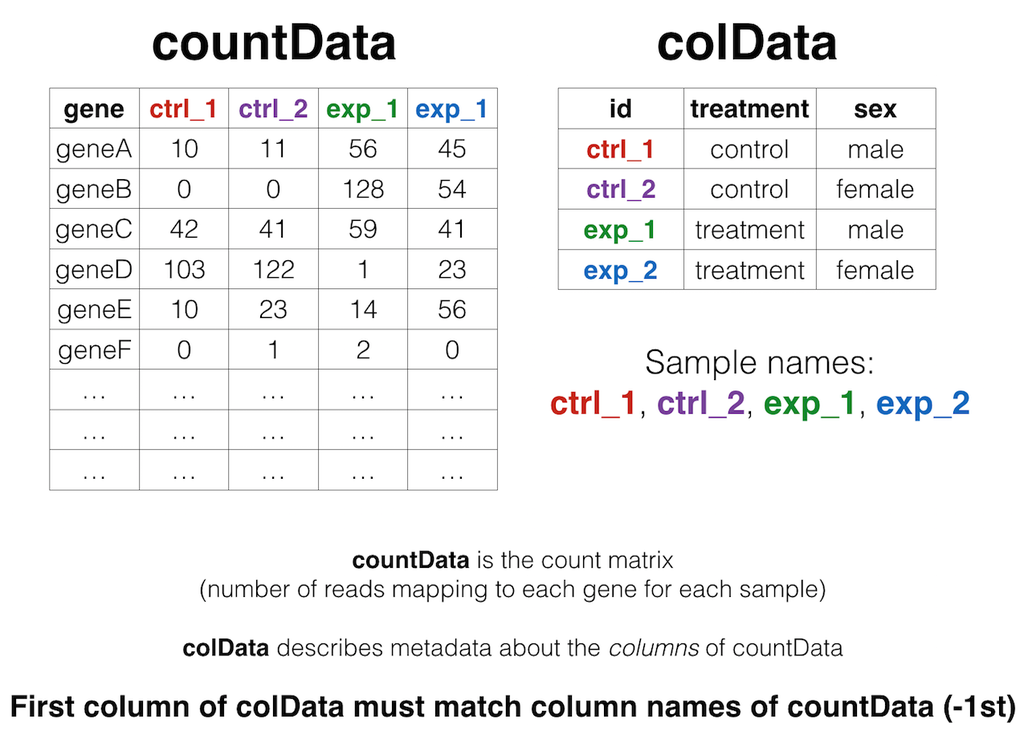

Countdata Structure

That is, we have two tables:

The “count matrix” (called the `countData` in DESeq-speak) – where *genes* are in *rows* and *samples* are in *columns*, and the number in each cell is the number of reads that mapped to exons in that gene for that sample: [**airway_scaledcounts.csv**](http://bims.fun/data/airway_scaledcounts.csv). The sample metadata (called the `colData` in DESeq-speak) – where *samples* are in *rows* and *metadata* about those samples are in *columns*: [**airway_metadata.csv**](http://bims.fun/data/airway_metadata.csv). It’s called the `colData` because this table supplies metadata/information about the columns of the `countData` matrix. Notice that the first column of `colData` must match the column names of `countData` (except the first, which is the gene ID column).[^1](http://bims.fun/r-rnaseq-airway.html#fn1)

# Import data

First, let’s load the **readr**, **dplyr**, and **ggplot2** packages. Then let’s import our data with readr’s `read_csv()` function (note: not read.csv()). Let’s read in the actual count data and the experimental metadata.

```r
library(readr)
library(dplyr)
library(ggplot2)

mycounts <- read_csv("../data/airway_scaledcounts.csv")
metadata <-  read_csv("../data/airway_metadata.csv")
```

Now, take a look at each.

```r
mycounts
```

```
## # A tibble: 38,694 x 9
##    ensgene         SRR1039508 SRR1039509 SRR1039512 SRR1039513 SRR1039516
##    <chr>                <dbl>      <dbl>      <dbl>      <dbl>      <dbl>
##  1 ENSG00000000003      723        486       904         445      1170
##  2 ENSG00000000005        0          0         0           0         0
##  3 ENSG00000000419      467        523       616         371       582
##  4 ENSG00000000457      347        258       364         237       318
##  5 ENSG00000000460       96.0       81.0      73.0        66.0     118
##  6 ENSG00000000938        0          0         1.00        0         2.00
##  7 ENSG00000000971     3413       3916      6000        4308      6424
##  8 ENSG00000001036     2328       1714      2640        1381      2165
##  9 ENSG00000001084      670        372       692         448       917
## 10 ENSG00000001167      426        295       531         178       740
## # ... with 38,684 more rows, and 3 more variables: SRR1039517 <dbl>,
## #   SRR1039520 <dbl>, SRR1039521 <dbl>
```

```r
metadata
```

```
## # A tibble: 8 x 4
##   id         dex     celltype geo_id
##   <chr>      <chr>   <chr>    <chr>
## 1 SRR1039508 control N61311   GSM1275862
## 2 SRR1039509 treated N61311   GSM1275863
## 3 SRR1039512 control N052611  GSM1275866
## 4 SRR1039513 treated N052611  GSM1275867
## 5 SRR1039516 control N080611  GSM1275870
## 6 SRR1039517 treated N080611  GSM1275871
## 7 SRR1039520 control N061011  GSM1275874
## 8 SRR1039521 treated N061011  GSM1275875
```

Notice something here. The sample IDs in the metadata sheet (SRR1039508, SRR1039509, etc.) exactly match the column names of the countdata, except for the first column, which contains the **Ensembl gene ID**. This is important, and we’ll get more strict about it later on.

# Poor man’s DGE (Differential Gene Expression)

Let’s look for differential gene expression. Note: this analysis is for demonstration only. NEVER do differential expression analysis this way!

Let’s start with an exercise.

## Exercise 1

If we look at our metadata, we see that the control samples are SRR1039508, SRR1039512, SRR1039516, and SRR1039520. This bit of code will take the `mycounts` data, `mutate()` it to add a column called `controlmean`, then `select()` only the gene name and this newly created column, and assigning the result to a new object called `meancounts`.

```r
meancounts <-
    mycounts %>%
        mutate(controlmean =
            (SRR1039508 + SRR1039512 + SRR1039516 + SRR1039520)/4) %>%
        select(ensgene, controlmean)
meancounts
```

```
## # A tibble: 38,694 x 2
##    ensgene         controlmean
##    <chr>                 <dbl>
##  1 ENSG00000000003     901
##  2 ENSG00000000005       0
##  3 ENSG00000000419     520
##  4 ENSG00000000457     340
##  5 ENSG00000000460      97.2
##  6 ENSG00000000938       0.750
##  7 ENSG00000000971    5219
##  8 ENSG00000001036    2327
##  9 ENSG00000001084     756
## 10 ENSG00000001167     528
## # ... with 38,684 more rows
```

1. Build off of this code, `mutate()` it once more (prior to the `select()`) function, to add another column called `treatedmean` that takes the mean of the expression values of the treated samples. Then `select()` only the `ensgene`, `controlmean` and `treatedmean` columns, assigning it to a new object called meancounts.

```r
meancounts <-
    mycounts %>%
        mutate(controlmean =
            (SRR1039508 + SRR1039512 + SRR1039516 + SRR1039520)/4) %>%
        mutate(treatedmean =
            (SRR1039509 + SRR1039513 + SRR1039517 + SRR1039521)/4) %>%
        select(ensgene, controlmean, treatedmean)
meancounts
```

```
## # A tibble: 38,694 x 3
##    ensgene         controlmean treatedmean
##    <chr>                 <dbl>       <dbl>
##  1 ENSG00000000003     901           658
##  2 ENSG00000000005       0             0
##  3 ENSG00000000419     520           546
##  4 ENSG00000000457     340           316
##  5 ENSG00000000460      97.2          78.8
##  6 ENSG00000000938       0.750         0
##  7 ENSG00000000971    5219          6688
##  8 ENSG00000001036    2327          1786
##  9 ENSG00000001084     756           578
## 10 ENSG00000001167     528           348
## # ... with 38,684 more rows
```

2. Directly comparing the raw counts is going to be problematic if we just happened to sequence one group at a higher depth than another. Later on we’ll do this analysis properly, normalizing by sequencing depth per sample using a better approach. But for now, `summarize()` the data to show the `sum` of the mean counts across all genes for each group.

```r
meancounts %>%
    summarize(sum(controlmean), sum(treatedmean))
```

```
## # A tibble: 1 x 2
##   `sum(controlmean)` `sum(treatedmean)`
##                <dbl>              <dbl>
## 1           23005324           22196524
```

## Exercise 2

1. Create a scatter plot showing the mean of the treated samples against the mean of the control samples.

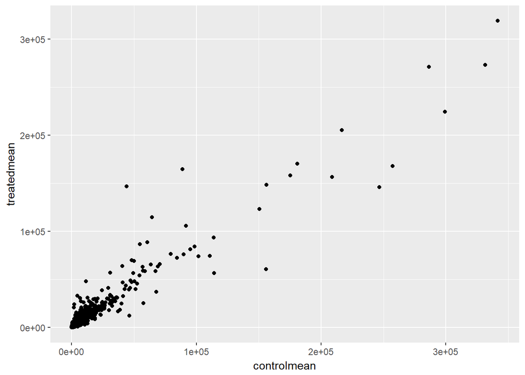

```r
ggplot(aes(x = controlmean, y = treatedmean), data = meancounts) +
    geom_point()
```

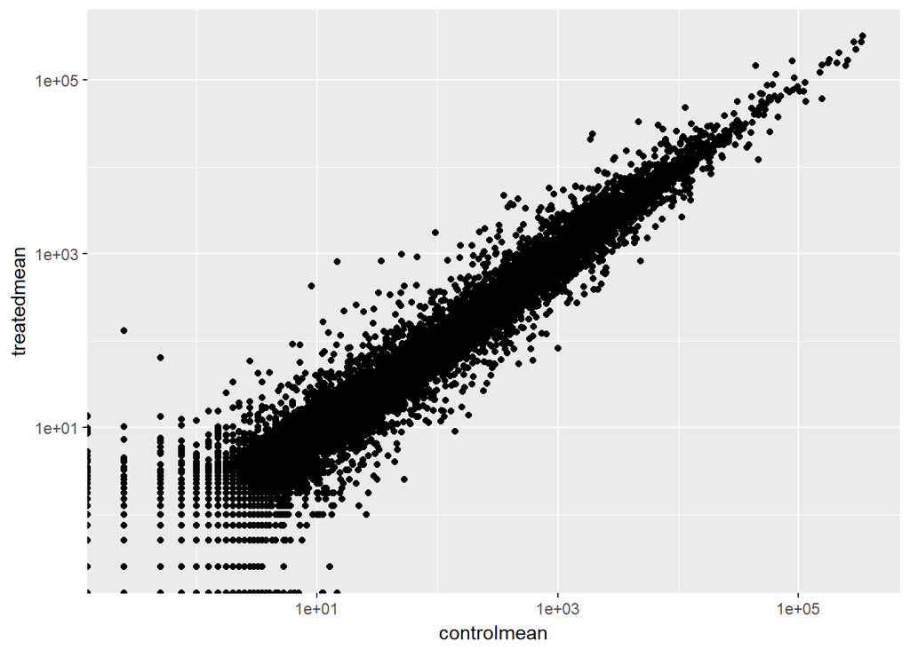

```r
ggplot(aes(x = controlmean, y = treatedmean), data = meancounts) +
    scale_x_log10() + scale_y_log10() +
    geom_point()
```

We can find candidate differentially expressed genes by looking for genes with a large change between control and dex-treated samples. We usually look at the $log2$ of the fold change, because this has better mathematical properties. On the absolute scale, upregulation goes from 1 to infinity, while downregulation is bounded by 0 and 1. On the log scale, upregulation goes from 0 to infinity, and downregulation goes from 0 to negative infinity. So, let’s mutate our `meancounts` object to add a `log2foldchange` column. Optionally pipe this to `View()`.

```r
meancounts %>%
    mutate(log2fc = log2(treatedmean/controlmean))
```

```
## # A tibble: 38,694 x 4
##    ensgene         controlmean treatedmean    log2fc
##    <chr>                 <dbl>       <dbl>     <dbl>
##  1 ENSG00000000003     901           658   -  0.453
##  2 ENSG00000000005       0             0    NaN
##  3 ENSG00000000419     520           546      0.0690
##  4 ENSG00000000457     340           316   -  0.102
##  5 ENSG00000000460      97.2          78.8 -  0.304
##  6 ENSG00000000938       0.750         0   -Inf
##  7 ENSG00000000971    5219          6688      0.358
##  8 ENSG00000001036    2327          1786   -  0.382
##  9 ENSG00000001084     756           578   -  0.387
## 10 ENSG00000001167     528           348   -  0.600
## # ... with 38,684 more rows
```

There are a couple of “weird” results. Namely, the `NaN` (“not a number”) and `-Inf` (negative infinity) results. The `NaN` is returned when you divide by zero and try to take the log. The `-Inf` is returned when you try to take the log of zero. It turns out that there are a lot of genes with zero expression. Let’s filter our `meancounts` data, mutate it to add the $log2(FoldChange)$, and when we’re happy with what we see, let’s *reassign* the result of that operation *back to the `meancounts` object*. *(Note: this is destructive. If you’re coding interactively like we’re doing now, before you do this it’s good practice to see what the result of the operation is prior to making the reassignment.)*

```r
# Try running the code first, prior to reassigning.
meancounts <- meancounts %>%
  filter(controlmean > 0 & treatedmean > 0) %>%
  mutate(log2fc = log2(treatedmean/controlmean))
meancounts
```

```
## # A tibble: 21,817 x 4
##    ensgene         controlmean treatedmean  log2fc
##    <chr>                 <dbl>       <dbl>   <dbl>
##  1 ENSG00000000003       901         658   -0.453
##  2 ENSG00000000419       520         546    0.0690
##  3 ENSG00000000457       340         316   -0.102
##  4 ENSG00000000460        97.2        78.8 -0.304
##  5 ENSG00000000971      5219        6688    0.358
##  6 ENSG00000001036      2327        1786   -0.382
##  7 ENSG00000001084       756         578   -0.387
##  8 ENSG00000001167       528         348   -0.600
##  9 ENSG00000001460       227         186   -0.290
## 10 ENSG00000001461      3170        2701   -0.231
## # ... with 21,807 more rows
```

A common threshold used for calling something differentially expressed is a $log2(FoldChange)$ of greater than 2 or less than -2. Let’s filter the dataset both ways to see how many genes are up or down-regulated.

```r
meancounts %>% filter(log2fc > 2)
```

```
## # A tibble: 250 x 4
##    ensgene         controlmean treatedmean log2fc
##    <chr>                 <dbl>       <dbl>  <dbl>
##  1 ENSG00000004799     270         1429      2.40
##  2 ENSG00000006788       2.75        19.8    2.84
##  3 ENSG00000008438       0.500        2.75   2.46
##  4 ENSG00000011677       0.500        2.25   2.17
##  5 ENSG00000015413       0.500        3.00   2.58
##  6 ENSG00000015592       0.500        2.25   2.17
##  7 ENSG00000046653     323         2126      2.72
##  8 ENSG00000070190       0.500        3.00   2.58
##  9 ENSG00000070388       3.50        17.5    2.32
## 10 ENSG00000074317       0.250        1.75   2.81
## # ... with 240 more rows
```

```r
meancounts %>% filter(log2fc < (-2))
```

```
## # A tibble: 367 x 4
##    ensgene         controlmean treatedmean log2fc
##    <chr>                 <dbl>       <dbl>  <dbl>
##  1 ENSG00000015520       32.0        6.00   -2.42
##  2 ENSG00000019186       26.5        1.75   -3.92
##  3 ENSG00000025423      295         54.2    -2.44
##  4 ENSG00000028277       88.2       22.0    -2.00
##  5 ENSG00000029559        1.25       0.250  -2.32
##  6 ENSG00000049246      405         93.0    -2.12
##  7 ENSG00000049247        1.25       0.250  -2.32
##  8 ENSG00000052344        2.25       0.250  -3.17
##  9 ENSG00000054179        3.00       0.250  -3.58
## 10 ENSG00000064201       30.0        6.50   -2.21
## # ... with 357 more rows
```

In total, we’ve got 617 differentially expressed genes, in either direction.

## Exercise 3

Look up help on `?inner_join` or Google around for help for using dplyr’s `inner_join()` to join two tables by a common column/key. You downloaded annotables_grch38.csv from the [data downloads page](http://bims.fun/data.html). Load this data with `read_csv()` into an object called `anno`. Pipe it to `View()` or click on the object in the Environment pane to view the entire dataset. This table links the unambiguous Ensembl gene ID to things like the gene symbol, full gene name, location, Entrez gene ID, etc.

```r
anno <- read_csv("../data/annotables_grch38.csv")
anno
```

```
## # A tibble: 66,531 x 9
##    ensgene  entrez symbol chr    start    end strand biotype description
##    <chr>     <int> <chr>  <chr>  <int>  <int>  <int> <chr>   <chr>
##  1 ENSG000~   7105 TSPAN6 X     1.01e8 1.01e8     -1 protei~ tetraspanin ~
##  2 ENSG000~  64102 TNMD   X     1.01e8 1.01e8      1 protei~ tenomodulin ~
##  3 ENSG000~   8813 DPM1   20    5.09e7 5.10e7     -1 protei~ dolichyl-pho~
##  4 ENSG000~  57147 SCYL3  1     1.70e8 1.70e8     -1 protei~ SCY1-like, k~
##  5 ENSG000~  55732 C1orf~ 1     1.70e8 1.70e8      1 protei~ chromosome 1~
##  6 ENSG000~   2268 FGR    1     2.76e7 2.76e7     -1 protei~ FGR proto-on~
##  7 ENSG000~   3075 CFH    1     1.97e8 1.97e8      1 protei~ complement f~
##  8 ENSG000~   2519 FUCA2  6     1.43e8 1.44e8     -1 protei~ fucosidase, ~
##  9 ENSG000~   2729 GCLC   6     5.35e7 5.36e7     -1 protei~ glutamate-cy~
## 10 ENSG000~   4800 NFYA   6     4.11e7 4.11e7      1 protei~ nuclear tran~
## # ... with 66,521 more rows
```

1. Take our newly created `meancounts` object, and `arrange()` it descending by the absolute value (`abs()`) of the `log2fc` column. The first few rows should look like this:

```r
meancounts %>%
    arrange(desc(abs(log2fc))) %>%
    head(3)
```

```
## # A tibble: 3 x 4
##   ensgene         controlmean treatedmean log2fc
##   <chr>                 <dbl>       <dbl>  <dbl>
## 1 ENSG00000179593       0.250       130     9.02
## 2 ENSG00000277196       0.500        63.8   6.99
## 3 ENSG00000109906      14.8         809     5.78
```

2. Continue on that pipeline, and `inner_join()` it to the `anno` data by the `ensgene` column. Either assign it to a temporary object or pipe the whole thing to `View` to take a look. What do you notice? Would you trust these results? Why or why not?

```r
result <-
    meancounts %>%
    arrange(desc(abs(log2fc))) %>%
    inner_join(anno, by = "ensgene")
result
```

```
## # A tibble: 21,995 x 12
##    ensgene   controlmean treatedmean log2fc  entrez symbol chr       start
##    <chr>           <dbl>       <dbl>  <dbl>   <int> <chr>  <chr>     <int>
##  1 ENSG0000~       0.250     130       9.02  2.47e2 ALOX1~ 17       8.04e6
##  2 ENSG0000~       0.500      63.8     6.99  1.03e8 AC007~ KI27073~ 1.38e5
##  3 ENSG0000~      14.8       809       5.78  7.70e3 ZBTB16 11       1.14e8
##  4 ENSG0000~      12.8         0.250  -5.67  2.85e3 MCHR1  22       4.07e7
##  5 ENSG0000~       9.00      427       5.57  1.02e4 ANGPT~ 1        1.12e7
##  6 ENSG0000~       0.250      10.2     5.36  4.32e3 MMP7   11       1.03e8
##  7 ENSG0000~       0.250       7.25    4.86  5.85e4 LY6G5B CHR_HSC~ 3.17e7
##  8 ENSG0000~       0.500      13.2     4.73  4.40e5 GPR179 17       3.83e7
##  9 ENSG0000~      25.5         1.00   -4.67  8.45e2 CASQ2  1        1.16e8
## 10 ENSG0000~      34.2       827       4.59  7.97e4 STEAP4 7        8.83e7
## # ... with 21,985 more rows, and 4 more variables: end <int>,
## #   strand <int>, biotype <chr>, description <chr>
```

We are ignoring the total read count and other aspects that are important for statistics.

# DESeq2 analysis

## DESeq2 package

Let’s do this the right way. DESeq2 is an R package for analyzing count-based NGS data like RNA-seq. It is available from [Bioconductor](http://www.bioconductor.org/). Bioconductor is a project to provide tools for analysing high-throughput genomic data including RNA-seq, ChIP-seq and arrays. You can explore Bioconductor packages [here](http://www.bioconductor.org/packages/release/BiocViews.html#___Software).

Bioconductor packages usually have great documentation in the form of vignettes. For a great example, take a look at the [DESeq2 vignette for analyzing count data](http://www.bioconductor.org/packages/release/bioc/vignettes/DESeq2/inst/doc/DESeq2.pdf). This 40+ page manual is packed full of examples on using DESeq2, importing data, fitting models, creating visualizations, references, etc.

Just like R packages from CRAN, you only need to install Bioconductor packages once ([instructions here](http://bims.fun/setup.html#bioconductor)), then load them every time you start a new R session.

```r
library(DESeq2)
citation("DESeq2")
```

```
##
##   Love, M.I., Huber, W., Anders, S. Moderated estimation of fold
##   change and dispersion for RNA-seq data with DESeq2 Genome
##   Biology 15(12):550 (2014)
##
## A BibTeX entry for LaTeX users is
##
##   @Article{,
##     title = {Moderated estimation of fold change and dispersion for RNA-seq data with DESeq2},
##     author = {Michael I. Love and Wolfgang Huber and Simon Anders},
##     year = {2014},
##     journal = {Genome Biology},
##     doi = {10.1186/s13059-014-0550-8},
##     volume = {15},
##     issue = {12},
##     pages = {550},
##   }
```

Take a second and read through all the stuff that flies by the screen when you load the DESeq2 package. When you first installed DESeq2 it may have taken a while, because DESeq2 depends on a number of other R packages (S4Vectors, BiocGenerics, parallel, IRanges, etc.) Each of these, in turn, may depend on other packages. These are all loaded into your working environment when you load DESeq2. Also notice the lines that start with `The following objects are masked from 'package:....` One example of this is the `rename()` function from the dplyr package. When the S4Vectors package was loaded, it loaded it’s own function called `rename()`. Now, if you wanted to use dplyr’s rename function, you’ll have to call it explicitly using this kind of syntax: `dplyr::rename()`. [See this Q&A thread for more](http://stackoverflow.com/questions/4879377/r-masked-functions).

## Importing data

DESeq works on a particular type of object called a DESeqDataSet. The DESeqDataSet is a single object that contains input values, intermediate calculations like how things are normalized, and all results of a differential expression analysis. You can construct a DESeqDataSet from a count matrix, a metadata file, and a formula indicating the design of the experiment. See the help for `?DESeqDataSetFromMatrix`. If you read through the [DESeq2 vignette](http://www.bioconductor.org/packages/release/bioc/vignettes/DESeq2/inst/doc/DESeq2.pdf) you’ll read about the structure of the data that you need to construct a DESeqDataSet object.

`DESeqDataSetFromMatrix` requires the count matrix (`countData` argument) to be a matrix or numeric data frame. either the row names or the first column of the `countData` must be the identifier you’ll use for each gene. The column names of `countData` are the sample IDs, and they must match the row names of `colData` (or the first column when `tidy=TRUE`). `colData` is an additional dataframe describing sample metadata. Both `colData` and `countData` must be regular `data.frame` objects – they can’t have the special `tbl` class wrapper created when importing with `readr::read_*`.

Let’s look at our mycounts and metadata again.

```r
mycounts
```

```
## # A tibble: 38,694 x 9
##    ensgene         SRR1039508 SRR1039509 SRR1039512 SRR1039513 SRR1039516
##    <chr>                <dbl>      <dbl>      <dbl>      <dbl>      <dbl>
##  1 ENSG00000000003      723        486       904         445      1170
##  2 ENSG00000000005        0          0         0           0         0
##  3 ENSG00000000419      467        523       616         371       582
##  4 ENSG00000000457      347        258       364         237       318
##  5 ENSG00000000460       96.0       81.0      73.0        66.0     118
##  6 ENSG00000000938        0          0         1.00        0         2.00
##  7 ENSG00000000971     3413       3916      6000        4308      6424
##  8 ENSG00000001036     2328       1714      2640        1381      2165
##  9 ENSG00000001084      670        372       692         448       917
## 10 ENSG00000001167      426        295       531         178       740
## # ... with 38,684 more rows, and 3 more variables: SRR1039517 <dbl>,
## #   SRR1039520 <dbl>, SRR1039521 <dbl>
```

```r
metadata
```

```
## # A tibble: 8 x 4
##   id         dex     celltype geo_id
##   <chr>      <chr>   <chr>    <chr>
## 1 SRR1039508 control N61311   GSM1275862
## 2 SRR1039509 treated N61311   GSM1275863
## 3 SRR1039512 control N052611  GSM1275866
## 4 SRR1039513 treated N052611  GSM1275867
## 5 SRR1039516 control N080611  GSM1275870
## 6 SRR1039517 treated N080611  GSM1275871
## 7 SRR1039520 control N061011  GSM1275874
## 8 SRR1039521 treated N061011  GSM1275875
```

```r
class(mycounts)
```

```
## [1] "tbl_df"     "tbl"        "data.frame"
```

```r
class(metadata)
```

```
## [1] "tbl_df"     "tbl"        "data.frame"
```

Remember, we read in our count data and our metadata using `read_csv()` which read them in as those “special” dplyr data frames / tbls. We’ll need to convert them back to regular data frames for them to work well with DESeq2.

```r
mycounts <- as.data.frame(mycounts)
metadata <- as.data.frame(metadata)
head(mycounts)
```

```
##           ensgene SRR1039508 SRR1039509 SRR1039512 SRR1039513 SRR1039516
## 1 ENSG00000000003        723        486        904        445       1170
## 2 ENSG00000000005          0          0          0          0          0
## 3 ENSG00000000419        467        523        616        371        582
## 4 ENSG00000000457        347        258        364        237        318
## 5 ENSG00000000460         96         81         73         66        118
## 6 ENSG00000000938          0          0          1          0          2
##   SRR1039517 SRR1039520 SRR1039521
## 1       1097        806        604
## 2          0          0          0
## 3        781        417        509
## 4        447        330        324
## 5         94        102         74
## 6          0          0          0
```

```r
head(metadata)
```

```
##           id     dex celltype     geo_id
## 1 SRR1039508 control   N61311 GSM1275862
## 2 SRR1039509 treated   N61311 GSM1275863
## 3 SRR1039512 control  N052611 GSM1275866
## 4 SRR1039513 treated  N052611 GSM1275867
## 5 SRR1039516 control  N080611 GSM1275870
## 6 SRR1039517 treated  N080611 GSM1275871
```

```r
class(mycounts)
```

```
## [1] "data.frame"
```

```r
class(metadata)
```

```
## [1] "data.frame"
```

Let’s check that the column names of our count data (except the first, which is `ensgene`) are the same as the IDs from our colData.

```r
names(mycounts)[-1]
```

```
## [1] "SRR1039508" "SRR1039509" "SRR1039512" "SRR1039513" "SRR1039516"
## [6] "SRR1039517" "SRR1039520" "SRR1039521"
```

```r
metadata$id
```

```
## [1] "SRR1039508" "SRR1039509" "SRR1039512" "SRR1039513" "SRR1039516"
## [6] "SRR1039517" "SRR1039520" "SRR1039521"
```

```r
names(mycounts)[-1] == metadata$id
```

```
## [1] TRUE TRUE TRUE TRUE TRUE TRUE TRUE TRUE
```

```r
all(names(mycounts)[-1] == metadata$id)
```

```
## [1] TRUE
```

Now we can move on to constructing the actual DESeqDataSet object. The last thing we’ll need to specify is a *design* – a *formula* which expresses how the counts for each gene depend on the variables in colData. Take a look at `metadata` again. The thing we’re interested in is the `dex` column, which tells us which samples are treated with dexamethasone versus which samples are untreated controls. We’ll specify the design with a tilde, like this: `design=~dex`. (The tilde is the shifted key to the left of the number 1 key on my keyboard. It looks like a little squiggly line). So let’s contruct the object and call it `dds`, short for our DESeqDataSet. If you get a warning about “some variables in design formula are characters, converting to factors” don’t worry about it. Take a look at the `dds` object once you create it.

```r
dds <- DESeqDataSetFromMatrix(countData = mycounts,
                              colData = metadata,
                              design = ~dex,
                              tidy = TRUE)
```

```
## Warning in DESeqDataSet(se, design = design, ignoreRank): some variables in
## design formula are characters, converting to factors
```

```r
dds
```

```
## class: DESeqDataSet
## dim: 38694 8
## metadata(1): version
## assays(1): counts
## rownames(38694): ENSG00000000003 ENSG00000000005 ...
##   ENSG00000283120 ENSG00000283123
## rowData names(0):
## colnames(8): SRR1039508 SRR1039509 ... SRR1039520 SRR1039521
## colData names(4): id dex celltype geo_id
```

## DESeq pipeline

Next, let’s run the DESeq pipeline on the dataset, and reassign the resulting object back to the same variable. Before we start, `dds` is a bare-bones DESeqDataSet. The `DESeq()` function takes a DESeqDataSet and returns a DESeqDataSet, but with lots of other information filled in (normalization, dispersion estimates, differential expression results, etc). Notice how if we try to access these objects before running the analysis, nothing exists.

```r
sizeFactors(dds)
```

```r
dispersions(dds)
```

```r
# results(dds)
```

Here, we’re running the DESeq pipeline on the `dds` object, and reassigning the whole thing back to `dds`, which will now be a DESeqDataSet populated with all those values. Get some help on `?DESeq` (notice, no “2” on the end). This function calls a number of other functions within the package to essentially run the entire pipeline (normalizing by library size by estimating the “size factors,” estimating dispersion for the negative binomial model, and fitting models and getting statistics for each gene for the design specified when you imported the data).

```r
dds <- DESeq(dds)
```

## Getting results

Since we’ve got a fairly simple design (single factor, two groups, treated versus control), we can get results out of the object simply by calling the `results()` function on the DESeqDataSet that has been run through the pipeline. The help page for `?results` and the vignette both have extensive documentation about how to pull out the results for more complicated models (multi-factor experiments, specific contrasts, interaction terms, time courses, etc.).

Note two things:

1. We’re passing the `tidy=TRUE` argument, which tells DESeq2 to output the results table with rownames as a first column called ‘row.’ If we didn’t do this, the gene names would be stuck in the row.names, and we’d have a hard time filtering or otherwise using that column.
2. This returns a regular old data frame. Try displaying it to the screen by just typing `res`. You’ll see that it doesn’t print as nicly as the data we read in with `read_csv`. We can add this “special” attribute to the raw data returned which just tells R to print it nicely.

```r
res <- results(dds, tidy = TRUE)
# res
res <- as_tibble(res)
res
```

```
## # A tibble: 38,694 x 7
##    row             baseMean log2FoldChange  lfcSE    stat  pvalue   padj
##    <chr>              <dbl>          <dbl>  <dbl>   <dbl>   <dbl>  <dbl>
##  1 ENSG00000000003  747           - 0.351   0.168 - 2.08   0.0371  0.163
##  2 ENSG00000000005    0            NA      NA      NA     NA      NA
##  3 ENSG00000000419  520             0.206   0.101   2.04   0.0413  0.176
##  4 ENSG00000000457  323             0.0245  0.145   0.169  0.866   0.962
##  5 ENSG00000000460   87.7         - 0.147   0.257 - 0.573  0.567   0.816
##  6 ENSG00000000938    0.319       - 1.73    3.49  - 0.496  0.620  NA
##  7 ENSG00000000971 5760             0.459   0.234   1.96   0.0500  0.201
##  8 ENSG00000001036 2025           - 0.228   0.125 - 1.83   0.0678  0.247
##  9 ENSG00000001084  652           - 0.253   0.203 - 1.25   0.212   0.495
## 10 ENSG00000001167  412           - 0.534   0.229 - 2.33   0.0197  0.105
## # ... with 38,684 more rows
```

Either click on the `res` object in the environment pane or pass it to `View()` to bring it up in a data viewer. Why do you think so many of the adjusted p-values are missing (`NA`)? Try looking at the `baseMean` column, which tells you the average overall expression of this gene, and how that relates to whether or not the p-value was missing. Go to the [DESeq2 vignette](http://www.bioconductor.org/packages/release/bioc/vignettes/DESeq2/inst/doc/DESeq2.pdf) and read the section about “Independent filtering and multiple testing.”

> The goal of independent filtering is to filter out those tests from the procedure that have no, or little chance of showing significant evidence, without even looking at the statistical result. Genes with very low counts are not likely to see significant differences typically due to high dispersion. This results in increased detection power at the same experiment-wide type I error [i.e., better FDRs].

## Exercise 4

1. Using a %>%, arrange the results by the adjusted p-value.

```r
res %>%
    arrange(padj)
```

```
## # A tibble: 38,694 x 7
##    row             baseMean log2FoldChange  lfcSE  stat    pvalue     padj
##    <chr>              <dbl>          <dbl>  <dbl> <dbl>     <dbl>    <dbl>
##  1 ENSG00000152583      955           4.37 0.237   18.4  8.87e-76 1.34e-71
##  2 ENSG00000179094      743           2.86 0.176   16.3  7.97e-60 6.04e-56
##  3 ENSG00000116584     2278          -1.03 0.0651 -15.9  5.80e-57 2.93e-53
##  4 ENSG00000189221     2384           3.34 0.212   15.7  9.24e-56 3.50e-52
##  5 ENSG00000120129     3441           2.97 0.204   14.6  5.31e-48 1.61e-44
##  6 ENSG00000148175    13494           1.43 0.100   14.2  6.93e-46 1.75e-42
##  7 ENSG00000178695     2685          -2.49 0.178  -14.0  2.11e-44 4.56e-41
##  8 ENSG00000109906      440           5.93 0.428   13.8  1.40e-43 2.65e-40
##  9 ENSG00000134686     2934           1.44 0.106   13.6  3.88e-42 6.53e-39
## 10 ENSG00000101347    14135           3.85 0.285   13.5  1.28e-41 1.94e-38
## # ... with 38,684 more rows
```

```r
res <-
    res %>%
    arrange(padj) %>%
    inner_join(anno, by = c("row" = "ensgene"))
```

3. How many are significant with an adjusted p-value <0.05? (Pipe to `filter()`).

```r
res %>%
    filter(padj < 0.05) %>%
    nrow()
```

```
## [1] 2187
```

Finally, let’s write out the significant results. See the help for `?write_csv`, which is part of the **readr** package (note: this is *not* the same as `write.csv` with a dot.). We can continue that pipe and write out the significant results to a file like so:

```r
res %>%
    filter(padj < 0.05) %>%
    write_csv("sigresults.csv")
```

You can open this file in Excel or any text editor (try it now).

# Data Visualization

## Plotting counts

DESeq2 offers a function called `plotCounts()` that takes a DESeqDataSet that has been run through the pipeline, the name of a gene, and the name of the variable in the `colData` that you’re interested in, and plots those values. See the help for `?plotCounts`. Let’s first see what the gene ID is for the CRISPLD2 gene using `res %>% filter(symbol=="CRISPLD2")`. Now, let’s plot the counts, where our `intgroup`, or “interesting group” variable is the “dex” column.

```r
res %>% filter(symbol=="CRISPLD2") %>% select(row)
```

```
## # A tibble: 1 x 1
##   row
##   <chr>
## 1 ENSG00000103196
```

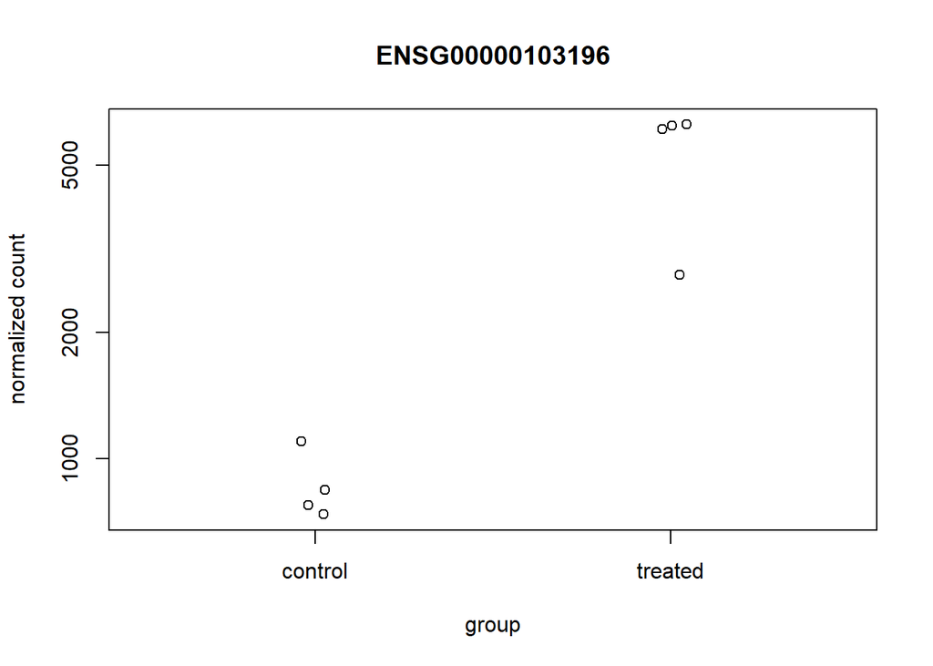

```r
plotCounts(dds, gene = "ENSG00000103196", intgroup = "dex")
```

That’s just okay. Keep looking at the help for `?plotCounts`. Notice that we could have actually returned the data instead of plotting. We could then pipe this to ggplot and make our own figure. Let’s make a boxplot.

```r
# Return the data
plotCounts(dds, gene = "ENSG00000103196", intgroup = "dex", returnData=TRUE)
```

```
##                count     dex
## SRR1039508  774.5002 control
## SRR1039509 6258.7915 treated
## SRR1039512 1100.2741 control
## SRR1039513 6093.0324 treated
## SRR1039516  736.9483 control
## SRR1039517 2742.1908 treated
## SRR1039520  842.5452 control
## SRR1039521 6224.9923 treated
```

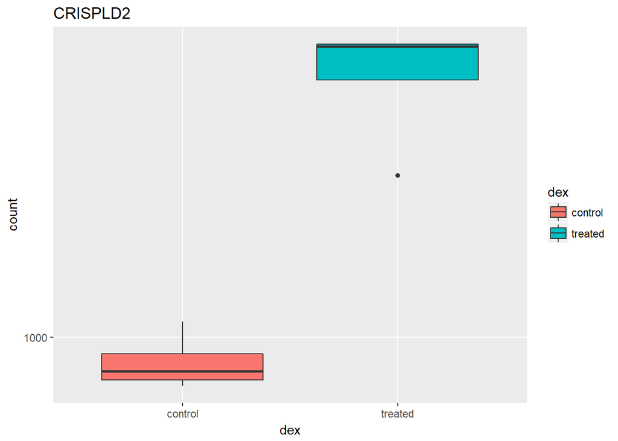

```r
# Plot it
plotCounts(dds, gene="ENSG00000103196", intgroup="dex", returnData=TRUE) %>%
    ggplot(aes(dex, count)) +
    geom_boxplot(aes(fill=dex)) +
    scale_y_log10() + ggtitle("CRISPLD2")
```

## MA & Volcano plots

Let’s make some commonly produced visualizations from this data. First, let’s mutate our results object to add a column called `sig` that evaluates to `TRUE` if `padj<0.05`, and `FALSE` if not, and `NA` if `padj` is also `NA`.

```r
# Create the new column
res <- res %>% mutate(sig = padj < 0.05)
res
```

```
## # A tibble: 38,957 x 16
##    row    baseMean log2FoldChange  lfcSE  stat     pvalue      padj entrez
##    <chr>     <dbl>          <dbl>  <dbl> <dbl>      <dbl>     <dbl>  <int>
##  1 ENSG0~      955           4.37 0.237   18.4   8.87e-76  1.34e-71   8404
##  2 ENSG0~      743           2.86 0.176   16.3   7.97e-60  6.04e-56   5187
##  3 ENSG0~     2278          -1.03 0.0651 -15.9   5.80e-57  2.93e-53   9181
##  4 ENSG0~     2384           3.34 0.212   15.7   9.24e-56  3.50e-52   4128
##  5 ENSG0~     3441           2.97 0.204   14.6   5.31e-48  1.61e-44   1843
##  6 ENSG0~    13494           1.43 0.100   14.2   6.93e-46  1.75e-42   2040
##  7 ENSG0~     2685          -2.49 0.178  -14.0   2.11e-44  4.56e-41 115207
##  8 ENSG0~      440           5.93 0.428   13.8   1.40e-43  2.65e-40   7704
##  9 ENSG0~     2934           1.44 0.106   13.6   3.88e-42  6.53e-39   1912
## 10 ENSG0~    14135           3.85 0.285   13.5   1.28e-41  1.94e-38  25939
## # ... with 38,947 more rows, and 8 more variables: symbol <chr>,
## #   chr <chr>, start <int>, end <int>, strand <int>, biotype <chr>,
## #   description <chr>, sig <lgl>
```

```r
# How many of each?
res %>%
    group_by(sig) %>%
    summarize(n = n())
```

```
## # A tibble: 3 x 2
##   sig       n
##   <lgl> <int>
## 1 F     13105
## 2 T      2187
## 3 NA    23665
```

## Exercise 5

Look up the Wikipedia articles on [MA plots](https://en.wikipedia.org/wiki/MA_plot) and volcano plots. An MA plot shows the average expression on the X-axis and the log fold change on the y-axis. A volcano plot shows the log fold change on the X-axis, and the $−log10$ of the p-value on the Y-axis (the more significant the p-value, the larger the $−log10$ of that value will be).

1. Make an MA plot. Use a $log10$-scaled x-axis, color-code by whether the gene is significant, and give your plot a title. It should look like this. What’s the deal with the gray points? Why are they missing? Go to the DESeq2 website on Bioconductor and look through the vignette for “Independent Filtering.”

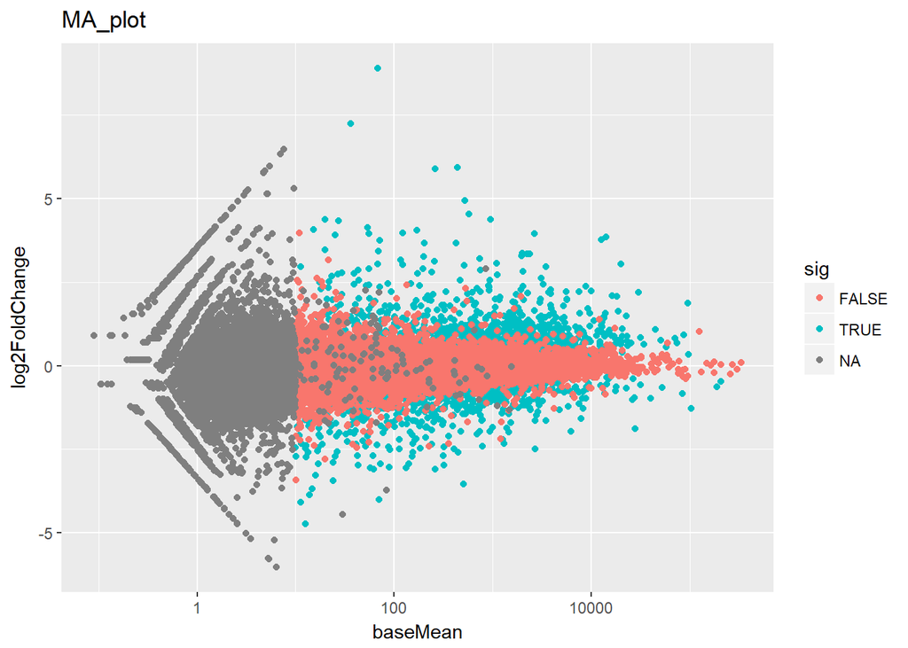

```r
# ggplot(aes(x = baseMean, y = log2FoldChange, color = sig), data = res) + scale_x_log10() + geom_point() + labs(title = "MA_plot")
ggplot(aes(x = baseMean, y = log2FoldChange), data = res) + scale_x_log10() + geom_point(aes(color = sig)) + ggtitle("MA_plot")
```

2. Make a volcano plot. Similarly, color-code by whether it’s significant or not.

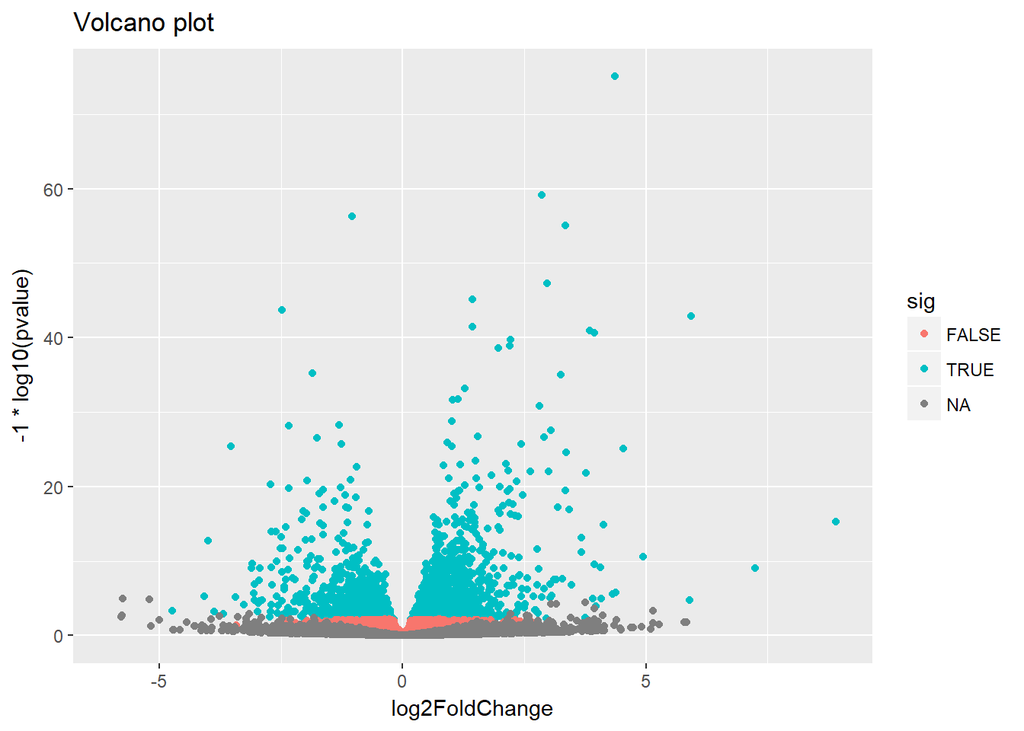

```r
ggplot(aes(x = log2FoldChange, y = -1 * log10(pvalue)), data = res) + geom_point(aes(color = sig)) + ggtitle("Volcano plot")
```

## Transformation

To test for differential expression we operate on raw counts. But for other downstream analyses like heatmaps, PCA, or clustering, we need to work with transformed versions of the data, because it’s not clear how to best compute a distance metric on untransformed counts. The go-to choice might be a log transformation. But because many samples have a zero count (and $log(0)=−\infty$, you might try using pseudocounts, i. e. $y=log(n+1)$ or more generally, $y=log(n+n_0)$, where $n$ represents the count values and $n_0$ is some positive constant.

But there are other approaches that offer better theoretical justification and a rational way of choosing the parameter equivalent to $n_0$, and they produce transformed data on the log scale that’s normalized to library size. One is called a *variance stabilizing transformation* (VST), and it also removes the dependence of the variance on the mean, particularly the high variance of the log counts when the mean is low.

```r
vsdata <- vst(dds, blind = FALSE)
vsdata
```

```
## class: DESeqTransform
## dim: 38694 8
## metadata(1): version
## assays(1): ''
## rownames(38694): ENSG00000000003 ENSG00000000005 ...
##   ENSG00000283120 ENSG00000283123
## rowData names(21): baseMean baseVar ... maxCooks dispFit
## colnames(8): SRR1039508 SRR1039509 ... SRR1039520 SRR1039521
## colData names(5): id dex celltype geo_id sizeFactor
```

## PCA

Let’s do some exploratory plotting of the data using principal components analysis on the variance stabilized data from above. Let’s use the DESeq2-provided `plotPCA` function. See the help for `?plotPCA` and notice that it also has a `returnData` option, just like `plotCounts`.

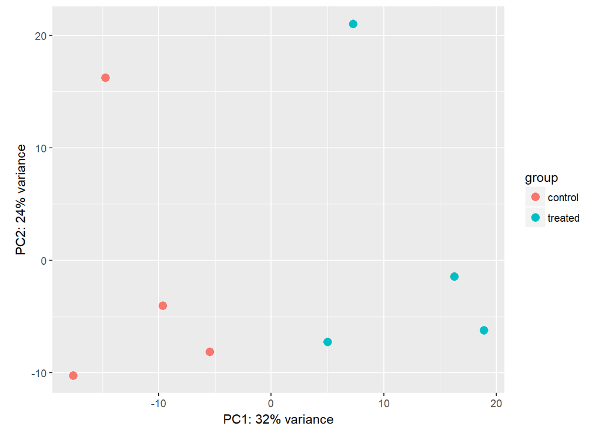

```r
plotPCA(vsdata, intgroup = "dex")
```

# Record `sessionInfo()`

The `sessionInfo()` prints version information about R and any attached packages. It’s a good practice to always run this command at the end of your R session and record it for the sake of reproducibility in the future.

[session information not shown]